# Assignment 4

Chad Pickering, 2/16/2017

Corresponded with: Patrick Vacek, Graham Smith, Ricky Safran, Sierra Tevlin, Nivi Achanta, Hannah Kosinovsky

Resources:

- Matplotlib Barcharts
- Several StackOverflow threads detailing how to cache retrieved information and use regular expressions in python
- Pandas documentation for 1.3 and preliminary 1.4 work
- http://stackoverflow.com/questions/24761998/pandas-compute-z-score-for-all-columns/24762240
- https://seaborn.pydata.org/examples/index.html
- Food reports API/documentation

In this assignment, you'll combine the assignment 3 data set with nutrition data from the [USDA Food Composition Databases](https://ndb.nal.usda.gov/ndb/search/list). The CSV file `fresh.csv` contains the fresh fruits and vegetables data you extracted in assignment 3.

The USDA Food Composition Databases have a [documented](https://ndb.nal.usda.gov/ndb/doc/index) web API that returns data in JSON format . You need a key in order to use the API. Only 1000 requests are allowed per hour, so it would be a good idea to use [caching](https://pypi.python.org/pypi/requests-cache).

[Sign up for an API key here](https://api.data.gov/signup/). The key will work with any Data.gov API. You may need the key again later in the quarter, so make sure you save it.

These modules may be useful:

- [requests](http://docs.python-requests.org/en/master/user/quickstart/)
- [requests_cache](https://pypi.python.org/pypi/requests-cache)
- [urlparse](https://docs.python.org/2/library/urlparse.html)
- [pandas](http://pandas.pydata.org/pandas-docs/stable/)

**Exercise 1.1.** Read the [search request documentation](https://ndb.nal.usda.gov/ndb/doc/apilist/API-SEARCH.md), then write a function called `ndb_search()` that makes a search request. The function should accept the search term as an argument. The function should return the search result items as a list (for 0 items, return an empty list).

Note that the search url is: `https://api.nal.usda.gov/ndb/search`

As an example, a search for `"quail eggs"` should return this list:

```
[{u'ds': u'BL',
  u'group': u'Branded Food Products Database',
  u'name': u'CHAOKOH, QUAIL EGG IN BRINE, UPC: 044738074186',
  u'ndbno': u'45094707',
  u'offset': 0},
 {u'ds': u'BL',
  u'group': u'Branded Food Products Database',
  u'name': u'L&W, QUAIL EGGS, UPC: 024072000256',
  u'ndbno': u'45094890',
  u'offset': 1},
 {u'ds': u'BL',
  u'group': u'Branded Food Products Database',
  u'name': u'BUDDHA, QUAIL EGGS IN BRINE, UPC: 761934535098',
  u'ndbno': u'45099560',
  u'offset': 2},
 {u'ds': u'BL',
  u'group': u'Branded Food Products Database',
  u'name': u'GRAN SABANA, QUAIL EGGS, UPC: 819140010103',
  u'ndbno': u'45169279',
  u'offset': 3},
 {u'ds': u'BL',
  u'group': u'Branded Food Products Database',
  u'name': u"D'ARTAGNAN, QUAIL EGGS, UPC: 736622102630",
  u'ndbno': u'45178254',
  u'offset': 4},
 {u'ds': u'SR',
  u'group': u'Dairy and Egg Products',
  u'name': u'Egg, quail, whole, fresh, raw',
  u'ndbno': u'01140',
  u'offset': 5}]
```

As usual, make sure you document and test your function.

**The following are my two functions that query the USDA database and specifically output a json object. The code is commented line-by-line for easy following.**

```python
import requests
import numpy as np
#from cachecontrol import CacheControl

# establish session and caching mechanism
#s = requests.session()
#cache = CacheControl(s)

# Key retrieved for data.gov
key = "6Mlkk3BcscviohRJeOd4nmIiJEe5LPFXroxzNoHh"

# Cache this block
from fastcache import clru_cache
@clru_cache(maxsize=128,typed=False)

# query on USDA db, output json object (list of items)
def ndb_search(term):
    # input: term (type chr): the term to search
    # output: json_obj (type list): list with each query item

    # url string + inputted search term
    search = "https://api.nal.usda.gov/ndb/search/?format=json&q="+term

    # append remainder of url (key info)
    search = search+"&sort=r&offset=0&api_key="+key+"&ds=Standard Reference" # sort = {n, r}

    # use caching mechanism and retrieve the data
    req = requests.get(search)

    # make json object
    json_obj = req.json()

    # return elements of json_obj (as "list", "item") when they are present; o/w empty list when KeyError
    try:
        list_out = json_obj["list"]["item"]
    except KeyError:
        list_out=[]
    return(list_out)
```

**Exercise 1.2.** Use your search function to get NDB numbers for the foods in the `fresh.csv` file. It's okay if you don't get an NDB number for every food, but try to come up with a strategy that gets most of them. Discuss your strategy in a short paragraph.

Hints:

- The foods are all raw and unbranded.
- You can test search terms with the [online search page](https://ndb.nal.usda.gov/ndb/search/list).
- You can convert the output of `ndb_search()` to a data frame with `pd.DataFrame()`.
- The string methods for [Python](https://docs.python.org/2/library/stdtypes.html#string-methods) and [Pandas](http://pandas.pydata.org/pandas-docs/stable/text.html#method-summary) are useful here. It's okay if you use *simple* regular expressions in the Pandas methods, although this exercise can be solved without them.
- You can merge data frames that have a column in common with `pd.merge()`.

**The following function uses a given search term to identify and return the correpsonding NDB identification number. If one is not found, an NaN is used as a placeholder.**

```python
# from the json object, get the ndb numbers
def ndb_get(term):
    # use previous function to get data for specific food
    search_x = ndb_search(term)
    # return ndb number or empty list (same strategy as above) if length of returned items is 0
    if len(search_x) == 0:
        return(np.nan)
    else:
        return(search_x[0]['ndbno'])
```

```python
# import the fresh data
import pandas as pd
import re # regex
fresh = pd.read_csv("fresh.csv")

# Take sixth column of fresh and append ' raw' because all searches include that string
food = fresh.iloc[:,5] + ' raw'

# For all food names, substitute any underscores with a space to makes the searches work with more precision
for x in range(len(food)):
    food[x] = re.sub('_', ' ', food[x])

# List comp. to call ndb_get function above for every food (search term)
ndb_val = [ndb_get(f) for f in food]

# Get kiwifruit manually (single exception), and enter into corresponding location in list
ndb_val[12] = ndb_get("kiwifruit")

# Using Series, make the ndb values its own df as name "ndb" with the same index as "fresh"
ndb_col = pd.DataFrame({"ndb":pd.Series(ndb_val)}, index = fresh.index)

# Concatenate the existing df "fresh" and df (column essentially) just created (axis=1 is like cbind())
nutr_df = pd.concat([fresh, ndb_col], axis=1)
nutr_df
```

|  | form | price_per_lb | yield | lb_per_cup | price_per_cup | food | type | ndb |
| --- | --- | --- | --- | --- | --- | --- | --- | --- |
| 0 | Fresh1 | 0.333412 | 0.520000 | 0.330693 | 0.212033 | watermelon | fruit | 09326 |
| 1 | Fresh1 | 0.535874 | 0.510000 | 0.374786 | 0.393800 | cantaloupe | fruit | 09181 |
| 2 | Fresh1 | 1.377962 | 0.740000 | 0.407855 | 0.759471 | tangerines | fruit | 09221 |
| 3 | Fresh1 | 2.358808 | 0.940000 | 0.319670 | 0.802171 | strawberries | fruit | 09316 |
| 4 | Fresh1 | 1.827416 | 0.940000 | 0.363763 | 0.707176 | plums | fruit | 09279 |
| 5 | Fresh1 | 1.035173 | 0.730000 | 0.407855 | 0.578357 | oranges | fruit | 09201 |
| 6 | Fresh1 | 6.975811 | 0.960000 | 0.319670 | 2.322874 | raspberries | fruit | 09302 |
| 7 | Fresh1 | 2.173590 | 0.560000 | 0.341717 | 1.326342 | pomegranate | fruit | 09286 |
| 8 | Fresh1 | 0.627662 | 0.510000 | 0.363763 | 0.447686 | pineapple | fruit | 09266 |
| 9 | Fresh1 | 3.040072 | 0.930000 | 0.363763 | 1.189102 | apricots | fruit | 09021 |
| 10 | Fresh1 | 0.796656 | 0.460000 | 0.374786 | 0.649077 | honeydew | fruit | 09184 |
| 11 | Fresh1 | 1.298012 | 0.620000 | 0.308647 | 0.646174 | papaya | fruit | 09226 |
| 12 | Fresh1 | 2.044683 | 0.760000 | 0.385809 | 1.037970 | kiwi | fruit | 09148 |
| 13 | Fresh1 | 3.592990 | 0.920000 | 0.341717 | 1.334548 | cherries | fruit | 09276 |
| 14 | Fresh1 | 0.566983 | 0.640000 | 0.330693 | 0.292965 | bananas | fruit | 09040 |
| 15 | Fresh1 | 1.567515 | 0.900000 | 0.242508 | 0.422373 | apples | fruit | 09003 |
| 16 | Fresh1 | 1.591187 | 0.960000 | 0.341717 | 0.566390 | peaches | fruit | 09236 |
| 17 | Fresh1 | 1.761148 | 0.910000 | 0.319670 | 0.618667 | nectarines | fruit | 09191 |
| 18 | Fresh1 | 1.461575 | 0.900000 | 0.363763 | 0.590740 | pears | fruit | 09252 |
| 19 | Fresh1 | 0.897802 | 0.490000 | 0.462971 | 0.848278 | grapefruit | fruit | 09117 |
| 20 | Fresh1 | 5.774708 | 0.960000 | 0.319670 | 1.922919 | blackberries | fruit | 09042 |
| 21 | Fresh1 | 2.093827 | 0.960000 | 0.330693 | 0.721266 | grapes | fruit | 09129 |
| 22 | Fresh1 | 4.734622 | 0.950000 | 0.319670 | 1.593177 | blueberries | fruit | 09050 |
| 23 | Fresh1 | 1.377563 | 0.710000 | 0.363763 | 0.705783 | mangoes | fruit | 09176 |
| 24 | Fresh1 | 3.213494 | 0.493835 | 0.396832 | 2.582272 | asparagus | vegetables | 11011 |
| 25 | Fresh, consumed with peel1 | 1.295931 | 0.970000 | 0.264555 | 0.353448 | cucumbers | vegetables | 11206 |
| 26 | Fresh, peeled1 | 1.295931 | 0.730000 | 0.264555 | 0.469650 | cucumbers | vegetables | 11206 |
| 27 | Fresh1 | 1.213039 | 0.950000 | 0.242508 | 0.309655 | lettuce_iceberg | vegetables | 11252 |
| 28 | Fresh1 | 1.038107 | 0.900000 | 0.352740 | 0.406868 | onions | vegetables | 11282 |
| 29 | Fresh1 | 2.471749 | 0.750000 | 0.319670 | 1.053526 | turnip_greens | vegetables | 11568 |
| 30 | Fresh1 | 2.569235 | 0.840000 | 0.308647 | 0.944032 | mustard_greens | vegetables | 11270 |
| 31 | Fresh1 | 0.564320 | 0.811301 | 0.264555 | 0.184017 | potatoes | vegetables | 11362 |
| 32 | Fresh1 | 2.630838 | 1.160000 | 0.286601 | 0.650001 | collard_greens | vegetables | 11161 |
| 33 | Fresh1 | 2.139972 | 0.846575 | 0.275578 | 0.696606 | green_beans | vegetables | 11052 |
| 34 | Fresh1 | 1.172248 | 0.458554 | 0.451948 | 1.155360 | acorn_squash | vegetables | 11482 |
| 35 | Fresh1 | 2.277940 | 0.820000 | 0.264555 | 0.734926 | red_peppers | vegetables | 11821 |
| 36 | Fresh green cabbage1 | 0.579208 | 0.778797 | 0.330693 | 0.245944 | cabbage | vegetables | 11503 |
| 37 | Fresh red cabbage1 | 1.056450 | 0.779107 | 0.330693 | 0.448412 | cabbage | vegetables | 11503 |
| 38 | Fresh1 | 0.918897 | 0.811301 | 0.440925 | 0.499400 | sweet_potatoes | vegetables | 11507 |
| 39 | Fresh1 | 1.639477 | 0.769500 | 0.396832 | 0.845480 | summer_squash | vegetables | 11475 |
| 40 | Fresh1 | 1.311629 | 0.900000 | 0.275578 | 0.401618 | radish | vegetables | 11429 |
| 41 | Fresh1 | 1.244737 | 0.714000 | 0.451948 | 0.787893 | butternut_squash | vegetables | 11485 |
| 42 | Fresh1 | 2.235874 | 0.740753 | 0.319670 | 0.964886 | avocados | vegetables | 09038 |
| 43 | Fresh1 | 2.807302 | 1.050000 | 0.286601 | 0.766262 | kale | vegetables | 11233 |
| 44 | Fresh1 | 2.213050 | 0.375309 | 0.385809 | 2.274967 | artichoke | vegetables | 11226 |
| 45 | Fresh1 | 3.213552 | 0.769474 | 0.352740 | 1.473146 | okra | vegetables | 11278 |
| 46 | Fresh1 | 1.410363 | 0.820000 | 0.264555 | 0.455022 | green_peppers | vegetables | 11333 |
| 47 | Fresh1 | 2.763553 | 1.060000 | 0.341717 | 0.890898 | brussels_sprouts | vegetables | 11098 |
| 48 | Fresh1 | 2.690623 | 0.540000 | 0.363763 | 1.812497 | corn_sweet | vegetables | 11900 |

**1.2 Strategy Discussion:** The ndb_search() function itself retrieves the entire .json object by concatenating the entire desired url, and the following supplementary function called ndb_get() retrieves the ndb values for all searched foods. In both cases, we do have to consider the case where the length of an element retrieved is zero - we merely return an empty list in the first case, and a "NaN" value in the second. Because the underscore in some of the food names does not properly match to searches, we can use regular expressions to substitute the underscores with spaces, then add "raw" (present in all foods) and search these new terms. The only food out of all 49 that presents additional problems is "kiwi"; in the .json object, this entry is identified by "kiwifruit" instead, so it is not found with the current functions. We then iterate through all of the food names in the "fresh" data frame with a list comprehension and use the Series function in pandas to make the ndb values their own data frame with the same index as "fresh". Finally, concatenate the existing data frame "fresh" and the one-column data frame just created, column-wise.

**Exercise 1.3.** Read the [food reports V2 documentation](https://ndb.nal.usda.gov/ndb/doc/apilist/API-FOOD-REPORTV2.md), then write a function called `ndb_report()` that requests a *basic* food report. The function should accept the NDB number as an argument and return the list of nutrients for the food.

Note that the report url is: `https://api.nal.usda.gov/ndb/V2/reports`

For example, for `"09279"` (raw plums) the first element of the returned list should be:

```
{u'group': u'Proximates',
 u'measures': [{u'eqv': 165.0,
   u'eunit': u'g',
   u'label': u'cup, sliced',
   u'qty': 1.0,
   u'value': u'143.93'},
  {u'eqv': 66.0,
   u'eunit': u'g',
   u'label': u'fruit (2-1/8" dia)',
   u'qty': 1.0,
   u'value': u'57.57'},
  {u'eqv': 151.0,
   u'eunit': u'g',
   u'label': u'NLEA serving',
   u'qty': 1.0,
   u'value': u'131.72'}],
 u'name': u'Water',
 u'nutrient_id': u'255',
 u'unit': u'g',
 u'value': u'87.23'}
```

Be sure to document and test your function.

```python
# Cache this block
from fastcache import clru_cache
@clru_cache(maxsize=128,typed=False)

# Outputs basic food report for known NDB number retrieved
def ndb_report(ndb_num):
    # key string
    key = "6Mlkk3BcscviohRJeOd4nmIiJEe5LPFXroxzNoHh"

    # The URL used (from documentation)
    url = "https://api.nal.usda.gov/ndb/V2/reports/?ndbno="+ndb_num+"&type=b&format=json&api_key="+key

    # use caching mechanism and retrieve the data
    req = requests.get(url)

    # make json object
    json_o = req.json()

    # return elements of json_obj when they are present; o/w empty list when KeyError
    try:
        # Within the json object, identify the precise lists/indexes to traverse
        list_out = json_o["foods"][0]["food"]["nutrients"]
    except KeyError:
        list_out=[]
    return(list_out)

[ndb_report(u'09279')[x]["name"] for x in range(len(ndb_report(u'09279')))] # names of all nutrients
```

[output not shown]

**The following is preliminary work for part 1.4. I have chosen six measures of nutrition: calories, protein, fiber, sugar, iron, and vitamin C. These are the main determinants of nutrition to me for the purposes of this assignment; this is not comprehensive.**

```python
### Run this cell only once

# Create desired column names for future data frame columns
col_names = ["kcal", "protein", "fiber", "sugar", "iron", "vitamin_c"]

# Choose one food and iterate through the lists to see the names of all nutrients for reference
# [ndb_report(u'09279')[x]["name"] for x in range(len(ndb_report(u'09279')))]

# Identify indexes of nutrition measures in json object
l = [1, 2, 5, 6, 8, 14]

# For each NDB number, give the nutrition information in the six indexes above
# Output is a list of 6 lists (one for each nutrient)
nut_out = [[ndb_report(x)[i]["value"] for x in ndb_val] for i in l]
for i in range(len(l)):
    nutr_df[col_names[i]] = nut_out[i]

# Make all column content numeric (floats)
nutr_df[["price_per_lb", "yield", "kcal", "protein", "fiber", "sugar", "iron", "vitamin_c"]] = nutr_df[["price_per_lb", "yield", "kcal", "protein", "fiber", "sugar", "iron", "vitamin_c"]].apply(pd.to_numeric)

# Create convenient subset of data frame for later use in modeling section
num_nut = nutr_df[["price_per_lb", "yield", "kcal", "protein", "fiber", "sugar", "iron", "vitamin_c"]]
nutr_df
```

[output not shown]

**Exercise 1.4.** Which foods provide the best combination of price, yield, and nutrition? You can use kilocalories as a measure of "nutrition" here, but more a detailed analysis is better. Use plots to support your analysis.

**Procedure/Analysis:** Here, I check the scatter matrix to first check the distributions of all of the numerical data, but also to identify any potential relationships between variables. The primary purpose of the question is to yield a measure of how good the price and yield of a food is combined with the selected nutrients, but it is worth pointing out a few two-way associations I see from the scatter matrix because if two (or more) variables are correlated with each other, it may introduce a certain exaggeration or bias into the model.

For example, price is at least mildly positively associated with most of the other variables (as price increases, kcal, protein, fiber, and vitamin C tend to as well) - this indicates that when the standard score of price is above 0 (above the mean), the standard scores for those other variables are likely to be above 0 as well. Protein has the same kind of mild positive relationship with kcal and protein that could introduce some minimal bias in the overall standard scores. These biases may produce artificially high (or low) standard scores that could impact a decision to buy certain products based on price, yield, and nutritional value.

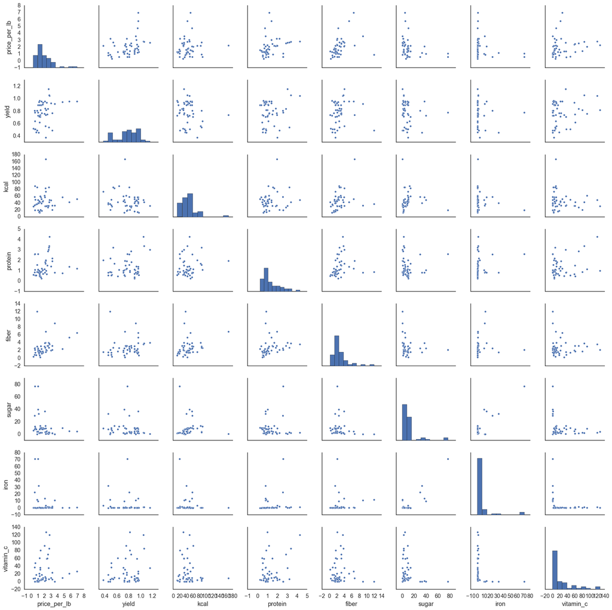

```python
import matplotlib.pyplot as plt
import seaborn as sns

sns.pairplot(num_nut.dropna())

sns.plt.show()
```

```python
# Run this cell only once

# List all columns in nutrition data frame
cols = list(num_nut.columns)

# Iterate over all columns to create a new column containing z-scores for each column
for col in cols:
    # Create new column for each existing; append '_zscore' to them
    col_zscore = col + '_zscore'
    # Calculate z-scores for each column
    num_nut[col_zscore] = (num_nut[col] - num_nut[col].mean())/num_nut[col].std(ddof=0)
# num_nut
```

**Because we want a higher overall score if price is lower, calorie count is lower, or sugar content is lower, we need to invert the z-scores of these specific columns so that when we add all scores row-wise, the sum will reflect an overall "optimized" score for all variables.**

```python
num_nut["price_per_lb_zscore"] = -1*num_nut["price_per_lb_zscore"]
num_nut["kcal_zscore"] = -1*num_nut["kcal_zscore"]
num_nut["sugar_zscore"] = -1*num_nut["sugar_zscore"]
num_nut
```

|  | price_per_lb | yield | kcal | protein | fiber | sugar | iron | vitamin_c | price_per_lb_zscore | yield_zscore | kcal_zscore | protein_zscore | fiber_zscore | sugar_zscore | iron_zscore | vitamin_c_zscore |
| --- | --- | --- | --- | --- | --- | --- | --- | --- | --- | --- | --- | --- | --- | --- | --- | --- |
| 0 | 0.333412 | 0.520000 | 30 | 0.61 | 0.4 | 6.20 | 0.24 | 8.100 | 1.259123 | -1.441425 | 0.571878 | -0.836302 | -1.094945 | 0.276372 | -0.352978 | -0.529010 |
| 1 | 0.535874 | 0.510000 | 34 | 0.84 | 0.9 | 7.86 | 0.21 | 36.700 | 1.101952 | -1.496440 | 0.417911 | -0.580045 | -0.859007 | 0.174882 | -0.355003 | 0.371317 |
| 2 | 1.377962 | 0.740000 | 43 | 0.50 | 0.2 | 9.90 | 0.20 | 31.000 | 0.448235 | -0.231116 | 0.071485 | -0.958860 | -1.189320 | 0.050159 | -0.355677 | 0.191881 |
| 3 | 2.358808 | 0.940000 | 32 | 0.67 | 2.0 | 4.89 | 0.41 | 58.800 | -0.313200 | 0.869166 | 0.494894 | -0.769452 | -0.339943 | 0.356464 | -0.341506 | 1.067025 |
| 4 | 1.827416 | 0.940000 | 46 | 0.70 | 1.4 | 9.92 | 0.17 | 9.500 | 0.099322 | 0.869166 | -0.043991 | -0.736028 | -0.623069 | 0.048936 | -0.357702 | -0.484938 |
| 5 | 1.035173 | 0.730000 | 49 | 1.04 | 2.5 | 40.00 | 10.00 | 0.087 | 0.714344 | -0.286130 | -0.159466 | -0.357213 | -0.104005 | -1.790118 | 0.305657 | -0.781259 |
| 6 | 6.975811 | 0.960000 | 52 | 1.20 | 6.5 | 4.42 | 0.69 | 26.200 | -3.897396 | 0.979194 | -0.274941 | -0.178948 | 1.783499 | 0.385199 | -0.322611 | 0.040777 |
| 7 | 2.173590 | 0.560000 | 83 | 1.67 | 4.0 | 13.67 | 0.30 | 10.200 | -0.169414 | -1.221369 | -1.468186 | 0.344707 | 0.603809 | -0.180334 | -0.348929 | -0.462902 |
| 8 | 0.627662 | 0.510000 | 50 | 0.54 | 1.4 | 9.85 | 0.29 | 47.800 | 1.030696 | -1.496440 | -0.197958 | -0.914293 | -0.623069 | 0.053216 | -0.349604 | 0.720745 |
| 9 | 3.040072 | 0.930000 | 48 | 1.40 | 2.0 | 9.24 | 0.39 | 10.000 | -0.842067 | 0.814151 | -0.120974 | 0.043884 | -0.339943 | 0.090510 | -0.342856 | -0.469198 |
| 10 | 0.796656 | 0.460000 | 36 | 0.54 | 0.8 | 8.12 | 0.17 | 18.000 | 0.899505 | -1.771510 | 0.340927 | -0.914293 | -0.906195 | 0.158986 | -0.357702 | -0.217358 |
| 11 | 1.298012 | 0.620000 | 43 | 0.47 | 1.7 | 7.82 | 0.25 | 60.900 | 0.510301 | -0.891285 | 0.071485 | -0.992284 | -0.481506 | 0.177327 | -0.352303 | 1.133133 |
| 12 | 2.044683 | 0.760000 | 61 | 1.14 | 3.0 | 8.99 | 0.31 | 92.700 | -0.069343 | -0.121088 | -0.621367 | -0.245797 | 0.131933 | 0.105795 | -0.348254 | 2.134196 |
| 13 | 3.592990 | 0.920000 | 33 | 0.80 | 9.0 | 0.20 | 11.00 | 0.300 | -1.271299 | 0.759137 | 0.456402 | -0.624612 | 2.963189 | 0.643205 | 0.373140 | -0.774554 |
| 14 | 0.566983 | 0.640000 | 89 | 1.09 | 2.6 | 12.23 | 0.26 | 8.700 | 1.077801 | -0.781257 | -1.699136 | -0.301505 | -0.056818 | -0.092295 | -0.351628 | -0.510122 |
| 15 | 1.567515 | 0.900000 | 52 | 0.26 | 2.4 | 10.39 | 0.12 | 4.600 | 0.301084 | 0.649109 | -0.274941 | -1.226258 | -0.151193 | 0.020201 | -0.361076 | -0.639190 |
| 16 | 1.591187 | 0.960000 | 39 | 0.91 | 1.5 | 8.39 | 0.25 | 6.600 | 0.282708 | 0.979194 | 0.225452 | -0.502054 | -0.575881 | 0.142478 | -0.352303 | -0.576230 |
| 17 | 1.761148 | 0.910000 | 44 | 1.06 | 1.7 | 7.89 | 0.28 | 5.400 | 0.150766 | 0.704123 | 0.032993 | -0.334930 | -0.481506 | 0.173048 | -0.350279 | -0.614006 |
| 18 | 1.461575 | 0.900000 | 57 | 0.36 | 3.1 | 9.75 | 0.18 | 4.300 | 0.383326 | 0.649109 | -0.467400 | -1.114842 | 0.179120 | 0.059330 | -0.357027 | -0.648634 |
| 19 | 0.897802 | 0.490000 | 37 | 0.88 | 12.0 | 0.08 | 12.00 | 0.020 | 0.820985 | -1.606468 | 0.302435 | -0.535479 | 4.378817 | 0.650541 | 0.440624 | -0.783368 |
| 20 | 5.774708 | 0.960000 | 43 | 1.39 | 5.3 | 4.88 | 0.62 | 21.000 | -2.964976 | 0.979194 | 0.071485 | 0.032743 | 1.217247 | 0.357075 | -0.327334 | -0.122918 |
| 21 | 2.093827 | 0.960000 | 57 | 0.81 | 3.9 | 37.00 | 14.00 | 1.500 | -0.107494 | 0.979194 | -0.467400 | -0.613470 | 0.556621 | -1.606701 | 0.575590 | -0.736778 |
| 22 | 4.734622 | 0.950000 | 57 | 0.74 | 2.4 | 9.96 | 0.28 | 9.700 | -2.157553 | 0.924180 | -0.467400 | -0.691461 | -0.151193 | 0.046490 | -0.350279 | -0.478642 |
| 23 | 1.377563 | 0.710000 | 60 | 0.82 | 1.6 | 13.66 | 0.16 | 36.400 | 0.448545 | -0.396158 | -0.582875 | -0.602328 | -0.528694 | -0.179723 | -0.358377 | 0.361873 |
| 24 | 3.213494 | 0.493835 | 20 | 2.20 | 2.1 | 1.88 | 2.14 | 5.600 | -0.976695 | -1.585367 | 0.956795 | 0.935212 | -0.292756 | 0.540492 | -0.224760 | -0.607710 |
| 25 | 1.295931 | 0.970000 | 12 | 0.59 | 0.7 | 1.38 | 0.22 | 3.200 | 0.511916 | 1.034208 | 1.264729 | -0.858585 | -0.953382 | 0.571061 | -0.354328 | -0.683262 |
| 26 | 1.295931 | 0.730000 | 12 | 0.59 | 0.7 | 1.38 | 0.22 | 3.200 | 0.511916 | -0.286130 | 1.264729 | -0.858585 | -0.953382 | 0.571061 | -0.354328 | -0.683262 |
| 27 | 1.213039 | 0.950000 | 14 | 0.90 | 1.2 | 1.97 | 0.41 | 2.800 | 0.576265 | 0.924180 | 1.187746 | -0.513196 | -0.717444 | 0.534989 | -0.341506 | -0.695854 |
| 28 | 1.038107 | 0.900000 | 40 | 1.10 | 1.7 | 4.24 | 0.21 | 7.400 | 0.712066 | 0.649109 | 0.186960 | -0.290364 | -0.481506 | 0.396204 | -0.355003 | -0.551046 |
| 29 | 2.471749 | 0.750000 | 32 | 1.50 | 3.2 | 0.81 | 1.10 | 60.000 | -0.400876 | -0.176102 | 0.494894 | 0.155300 | 0.226308 | 0.605910 | -0.294943 | 1.104801 |
| 30 | 2.569235 | 0.840000 | 27 | 2.86 | 3.2 | 1.32 | 1.64 | 70.000 | -0.476555 | 0.319025 | 0.687353 | 1.670558 | 0.226308 | 0.574729 | -0.258502 | 1.419601 |
| 31 | 0.564320 | 0.811301 | 58 | 2.57 | 2.5 | 30.00 | 23.00 | 0.021 | 1.079869 | 0.161141 | -0.505892 | 1.347451 | -0.104005 | -1.178730 | 1.182938 | -0.783337 |
| 32 | 2.630838 | 1.160000 | 32 | 3.02 | 4.0 | 0.46 | 0.47 | 35.300 | -0.524377 | 2.079475 | 0.494894 | 1.848823 | 0.603809 | 0.627309 | -0.337457 | 0.327245 |
| 33 | 2.139972 | 0.846575 | 31 | 1.83 | 2.7 | 3.26 | 1.03 | 12.200 | -0.143316 | 0.355197 | 0.533386 | 0.522973 | -0.009630 | 0.456120 | -0.299666 | -0.399942 |
| 34 | 1.172248 | 0.458554 | 40 | 0.80 | 1.5 | 33.00 | 32.00 | 0.140 | 0.607932 | -1.779466 | 0.186960 | -0.624612 | -0.575881 | -1.362146 | 1.790286 | -0.779591 |
| 35 | 2.277940 | 0.820000 | 31 | 0.99 | 2.1 | 4.20 | 0.43 | 127.700 | -0.250421 | 0.208997 | 0.533386 | -0.412921 | -0.292756 | 0.398650 | -0.340156 | 3.235996 |
| 36 | 0.579208 | 0.778797 | 19 | 2.60 | 2.1 | 77.00 | 71.00 | 0.030 | 1.068311 | -0.017677 | 0.995287 | 1.380876 | -0.292756 | -4.052252 | 4.422128 | -0.783054 |
| 37 | 1.056450 | 0.779107 | 19 | 2.60 | 2.1 | 77.00 | 71.00 | 0.030 | 0.697826 | -0.015974 | 0.995287 | 1.380876 | -0.292756 | -4.052252 | 4.422128 | -0.783054 |
| 38 | 0.918897 | 0.811301 | 86 | 1.57 | 3.0 | 4.18 | 0.61 | 2.400 | 0.804609 | 0.161141 | -1.583661 | 0.233291 | 0.131933 | 0.399872 | -0.328009 | -0.708446 |
| 39 | 1.639477 | 0.769500 | 18 | 1.20 | 1.2 | 2.39 | 0.40 | 18.000 | 0.245220 | -0.068824 | 1.033779 | -0.178948 | -0.717444 | 0.509311 | -0.342181 | -0.217358 |
| 40 | 1.311629 | 0.900000 | 16 | 0.68 | 1.6 | 1.86 | 0.34 | 14.800 | 0.499730 | 0.649109 | 1.110762 | -0.758311 | -0.528694 | 0.541714 | -0.346230 | -0.318094 |
| 41 | 1.244737 | 0.714000 | 45 | 1.00 | 2.0 | 2.20 | 0.70 | 21.000 | 0.551659 | -0.374152 | -0.005499 | -0.401780 | -0.339943 | 0.520927 | -0.321936 | -0.122918 |
| 42 | 2.235874 | 0.740753 | 167 | 1.96 | 6.8 | 0.30 | 0.61 | 8.800 | -0.217765 | -0.226972 | -4.701494 | 0.667814 | 1.925061 | 0.637091 | -0.328009 | -0.506974 |
| 43 | 2.807302 | 1.050000 | 49 | 4.28 | 3.6 | 2.26 | 1.47 | 120.000 | -0.661367 | 1.474320 | -0.159466 | 3.252665 | 0.415058 | 0.517259 | -0.269974 | 2.993600 |
| 44 | 2.213050 | 0.375309 | 73 | 2.00 | 1.6 | 9.60 | 3.40 | 4.000 | -0.200047 | -2.237431 | -1.083268 | 0.712380 | -0.528694 | 0.068500 | -0.139731 | -0.658078 |
| 45 | 3.213552 | 0.769474 | 33 | 1.93 | 3.2 | 1.48 | 0.62 | 23.000 | -0.976741 | -0.068969 | 0.456402 | 0.634389 | 0.226308 | 0.564947 | -0.327334 | -0.059958 |
| 46 | 1.410363 | 0.820000 | 20 | 0.86 | 1.7 | 2.40 | 0.34 | 80.400 | 0.423082 | 0.208997 | 0.956795 | -0.557762 | -0.481506 | 0.508699 | -0.346230 | 1.746992 |
| 47 | 2.763553 | 1.060000 | 43 | 3.38 | 3.8 | 2.20 | 1.40 | 85.000 | -0.627405 | 1.529334 | 0.071485 | 2.249921 | 0.509433 | 0.520927 | -0.274698 | 1.891800 |
| 48 | 2.690623 | 0.540000 | 86 | 3.22 | 2.7 | 3.22 | 0.52 | 6.800 | -0.570789 | -1.331397 | -1.583661 | 2.071655 | -0.009630 | 0.458566 | -0.334083 | -0.569934 |

**Procedure:** Finally, after all z-scores are correctly calculated, we sum the scores row-wise to yield a "standard additive score" for each food. This measure is a non-weighted relative index; in other words, for the eight variables we are measuring, these additive scores tell us which foods most satisfy our conditions. The larger scores have the best combinations of the eight variables and the lower scores (negative) have the worst combinations of the eight variables. In other words, the foods that scored the best either had mild to moderately high z-scores in most or all categories that summed to yield high additive scores, or they had extremely high values relative to the mean in only a small subset of the variables but the average to below-average performance in the other variables did not decrease the food's overall additive measure enough to bring it back down.

Note that each of the eight variables are weighted equally here. In a future model for a potential client, for example, weights could be assigned to each of the variables according to their relative importance in the model. Additive weights would shift the mean of the standard scores away from 0 without changing the variance, whereas multiplicative weights would increase or decrease the variance. The method of weighting for each of the eight variables would have to be determined based on the situation.

```python
# Subset just z-score columns, sum row-wise, and sort in descending order of overall additive score
z_scores = num_nut.ix[:,8:16]
z_scores["additive_score"] = z_scores.sum(axis=1)
z_scores = pd.concat([nutr_df["food"], z_scores], axis=1)
final_standard = z_scores.sort_values(by="additive_score", ascending=False)
overall_scores = final_standard[["food", "additive_score"]]
overall_scores
```

|  | food | additive_score |
| --- | --- | --- |
| 43 | kale | 7.562095 |
| 47 | brussels_sprouts | 5.870799 |
| 32 | collard_greens | 5.119721 |
| 30 | mustard_greens | 4.162517 |
| 19 | grapefruit | 3.668087 |
| 35 | red_peppers | 3.080773 |
| 36 | cabbage | 2.720864 |
| 13 | cherries | 2.524608 |
| 46 | green_peppers | 2.459068 |
| 37 | cabbage | 2.352082 |
| 29 | turnip_greens | 1.715293 |
| 31 | potatoes | 1.199434 |
| 3 | strawberries | 1.023447 |
| 33 | green_beans | 1.015121 |
| 12 | kiwi | 0.966074 |
| 27 | lettuce_iceberg | 0.955180 |
| 40 | radish | 0.849987 |
| 25 | cucumbers | 0.532357 |
| 45 | okra | 0.449044 |
| 28 | onions | 0.266421 |
| 39 | summer_squash | 0.263554 |
| 16 | peaches | -0.376637 |
| 41 | butternut_squash | -0.493643 |
| 17 | nectarines | -0.719791 |
| 20 | blackberries | -0.757485 |
| 26 | cucumbers | -0.787981 |
| 11 | papaya | -0.825133 |
| 38 | sweet_potatoes | -0.889270 |
| 9 | apricots | -1.166492 |
| 1 | cantaloupe | -1.224433 |
| 4 | plums | -1.228303 |
| 24 | asparagus | -1.254790 |
| 18 | pears | -1.317018 |
| 21 | grapes | -1.420439 |
| 6 | raspberries | -1.485227 |
| 15 | apples | -1.682264 |
| 8 | pineapple | -1.776706 |
| 23 | mangoes | -1.837737 |
| 48 | corn_sweet | -1.869273 |
| 2 | tangerines | -1.973213 |
| 0 | watermelon | -2.147288 |
| 5 | oranges | -2.458190 |
| 34 | acorn_squash | -2.536518 |
| 14 | bananas | -2.714960 |
| 42 | avocados | -2.751249 |
| 10 | honeydew | -2.767640 |
| 7 | pomegranate | -2.902619 |
| 22 | blueberries | -3.325858 |
| 44 | artichoke | -4.066370 |

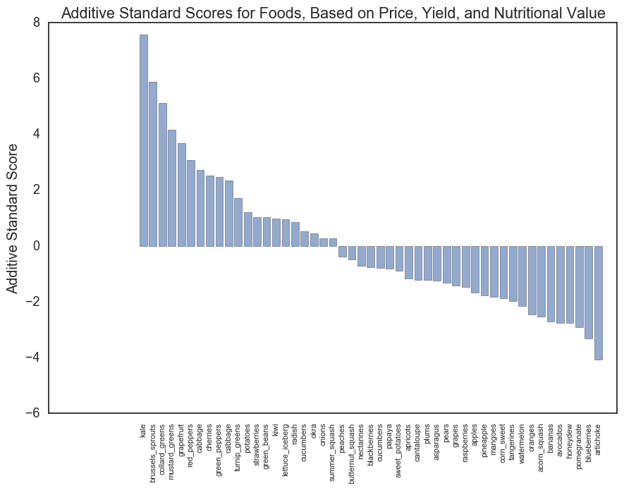

```python
# Graphical representation of the scores
import numpy as np
import seaborn as sns
import matplotlib.pyplot as plt

lbls = list(overall_scores["food"])
indexes = np.arange(len(overall_scores))
scores = list(overall_scores["additive_score"])

plt.bar(indexes, scores, align = 'center', alpha = 0.6)
plt.xticks(indexes, lbls, rotation=90, fontsize = 8)
plt.ylabel('Additive Standard Score')
plt.title('Additive Standard Scores for Foods, Based on Price, Yield, and Nutritional Value')

plt.show()
```

**Answer:** In conclusion, we can see that **kale, brussels sprouts, and collard greens** are the top three best picks for the variables we have specified. Additionally, artichokes, blueberries, and pomegranates are the three worst. Let's see why they got the scores they did to potentially refine our model in the future.

```python
best_3 = final_standard.head(3)
worst_3 = final_standard.tail(3)
pd.concat([best_3, worst_3], axis=0)
```

|  | food | price_per_lb_zscore | yield_zscore | kcal_zscore | protein_zscore | fiber_zscore | sugar_zscore | iron_zscore | vitamin_c_zscore | additive_score |
| --- | --- | --- | --- | --- | --- | --- | --- | --- | --- | --- |
| 43 | kale | -0.661367 | 1.474320 | -0.159466 | 3.252665 | 0.415058 | 0.517259 | -0.269974 | 2.993600 | 7.562095 |
| 47 | brussels_sprouts | -0.627405 | 1.529334 | 0.071485 | 2.249921 | 0.509433 | 0.520927 | -0.274698 | 1.891800 | 5.870799 |
| 32 | collard_greens | -0.524377 | 2.079475 | 0.494894 | 1.848823 | 0.603809 | 0.627309 | -0.337457 | 0.327245 | 5.119721 |
| 7 | pomegranate | -0.169414 | -1.221369 | -1.468186 | 0.344707 | 0.603809 | -0.180334 | -0.348929 | -0.462902 | -2.902619 |
| 22 | blueberries | -2.157553 | 0.924180 | -0.467400 | -0.691461 | -0.151193 | 0.046490 | -0.350279 | -0.478642 | -3.325858 |
| 44 | artichoke | -0.200047 | -2.237431 | -1.083268 | 0.712380 | -0.528694 | 0.068500 | -0.139731 | -0.658078 | -4.066370 |

**Analysis:** We can see that for kale, for example, high yield, protein, and vitamin C scores relative to their column-wise means easily made this the number one choice. We see a similar trend amongst the other two top choices; while the price may be slightly on the high side, and the iron content is slightly below average, yield, protein content, and vitamin C are all above average, and therefore impact the final score.

As for the low performers, price, especially with blueberries, is on the high side. Calories, iron, and vitamin C content also seems to be factors pulling down the scores. But, for these lower performers, there does not seem to be a "common culprit" (or set thereof) for each food leading to a lower score; rather, it seems that most values for each food are slightly to mildly below average, with a few exceptions, leading to a low final score.

It should also be noted that all of the z-scores that are added to create our additive standard scores are calculated relative to the body of data that we have now. If more foods were scraped and added to the data frame, we would get a more accurate and complete understanding of the variables and how they interact, as well as how different foods stack up in comparison with one another. We would also be able to identify more important variables from the basic food reports and include those in our model. And, of course, adding weights relative to importance would be a critical and exciting feature of a future model.